# Deconvolution

In a 10x Visium dataset, each spot may be comprised of a several cells (1-10 cells per spot on average), that in turn may be of different types. Therefore, deconvolution could be used to explore which cell types are included in each spot. There are two primary categories for deconvolution methods:

1. Reference-based
2. Reference-free

The former takes as input a single-cell RNA-seq dataset, from which it tries to infer the cell types existing in the spatial data. The latter is based on clustering methods (frequentist or Bayesian).

In this dashboard, the user can select between two deconvolution methodologies, one reference-based (SPOTlight) and one reference-free (BayesSpace).

## SPOTlight

**Data**

The minimum requirements for SPOTlight are:

- A sparse matrix from the spatial data with genes as rows and and spots as columns. Both raw and normalized data are acceptable.
- A sparse matrix from the single-cell data with genes as rows and and cell as columns. Both raw and normalized data are acceptable.
- A vector mapping each cell from the single-cell data to a cell-type.

**Cell-type related gene markers**

Once the data is uploaded, the next step requires to assign marker genes for each cell identity. To do so, we “measure the importance” of a gene for a cell type using a predetermined metric such as LogFC, AUC or pct.expressed.

Clearly, to ensure reliable results in this analysis, all the typical preprocessing steps (quality control, normalization, feature selection) are required.

**Cell downsampling**

Next, and to speed up the process, we can randomly select a number, N (determine the value), cells per cell identity. If a cell type is comprised of less than N cells, all of them will be used. The number N depends on the heterogeneity between the cell types. If the cell types display high biological difference, fewer cells can be used. Otherwise, a larger N should be selected in order to make it feasible to distinguish the cell identities.

**Deconvolution**

As soon as the previous steps have been undertaken, the spot deconvolution can be ran. This includes two steps: (i) model training and (ii) spots deconvolution

**Results**

The output of the SPOTlight is a matrix assigning to each spot a distribution of the cell types it comprises of. More specifically, the matrix has the spots as rows, the cell types as columns, whilst the values correspond to the proportion of the specific cell type that appears in the respective spot.

To evaluate the validity of the results, the user can create investigate the following aspects:

1. Topic profiling. Evaluate how specific each topic signature is for each cell identity. Ideally each cell identity will have a unique topic profile associated to it.
2. Homogeneity of topic profiling within cells of the same identity. This ensures that the model has detected a consistent signature for all the cells from the same cell identity.
3. Model performance. Using the model’s residuals, the biological signal not explained by the model arises.

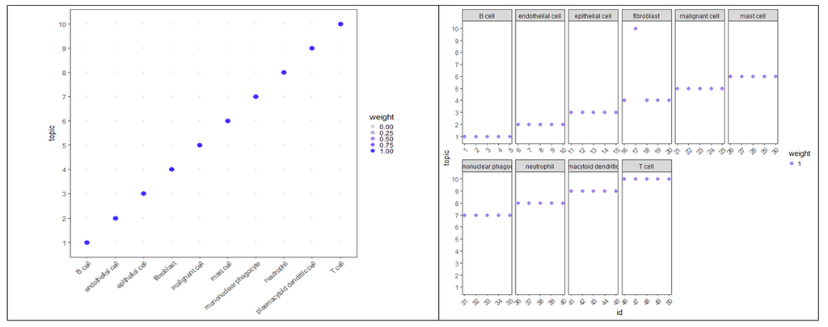

After confirming the validity of the results, the user can now interpret them and make inference based on them. Specifically, they can:

1. Investigate the genes associated with each topic
2. Examine correlation between the cell types
3. Explore the cell types that more often appear within the same spot.

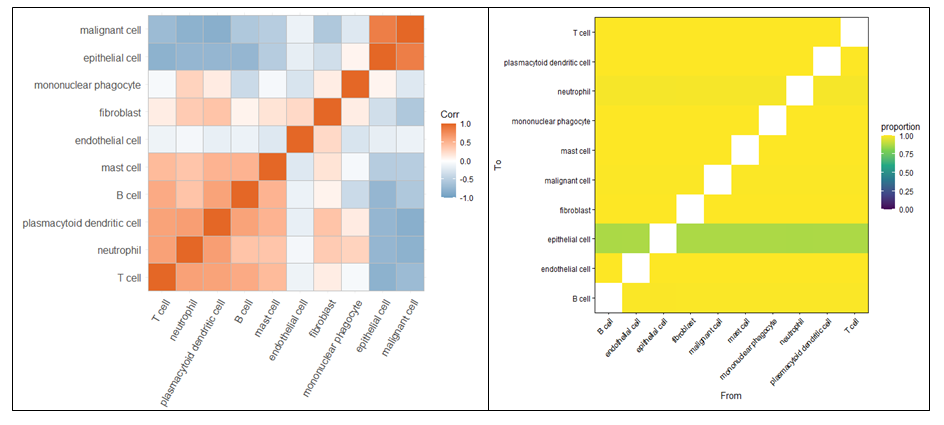

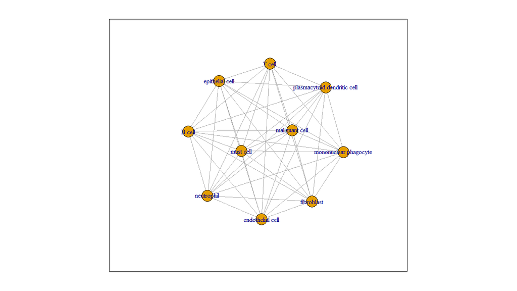